# PRIMERA CLASE: REGRESIÓN LINEAL

Maestría en Investigación Operativa y Estadística

[figure not shown]

# INTRODUCCIÓN

## DOCENTES

### Héctor Hernán Montes García.

Ingeniero industrial de la Universidad Tecnológica de Pereira.

Estudios en Maestría en Ciencias con orientación en Matemáticas

Desempeño laboral

Científico de datos con más de 3 años de experiencia en la construcción de modelos de aprendizaje automático y soluciones de minería de datos para obtener mejores conocimientos comerciales. Experiencia utilizando SQL, bibliotecas de Python (matplotlib, seaborn, flask, scikit-learn, pandas, numpy), modelos matemáticos y estadísticos para ofrecer soluciones robustas que agregan valor al negocio.

Ha trabajado para clientes del sector industrial y financiero en México y Colombia, en áreas tales como:

- Mantenimiento predictivo
- Diseño de campañas comerciales basadas en datos
- Reconocimiento de imágenes
- Modelos de procesamiento de lenguaje natural (NER).

### Julián Piedrahíta Monroy

Ingeniero industrial.

Magíster en desarrollo agroindustrial

Universidad Tecnológica de Pereira

Desempeño laboral

- Consultor en soluciones análiticas para instituciones educativas.
- Analista de datos en el observatorio social de la UTP.
- Actualmente diseñador de tableros informativos (dashboards) para la Universidad Pedagógica Nacional de Bogotá y la misma Universidad Tecnológica de Pereira.
- Docente catedrático en el área de informática y estadística general.
- Uso principal del lenguaje R y sus librerias Tidyverse, RMarkdown, RShiny y otras.

## Contenido del curso

- T1. Regresión Lineal, suposiciones y requisitos.
- T2. Estimación de los parámetros e interpretación de los valores.
- T3. Pruebas de hipótesis relacionadas con los parámetros.
- T4. Evaluación de modelos de acuerdo a las suposiciones de normalidad e independencia.
- T5. Transformaciones de las variables, y sus implicaciones en las pruebas de hipótesis.
- T6. Series de Tiempo. Estacionariedad y cómo obtener una serie estacionaria a partir de una que no lo es. Correlogramas.
- T7. Modelos de Box y Cox. Estimación de parámetros.
- T8. Criterios de evaluación de un modelo de series de tiempo. Transformaciones.

## Bibliografía.

Regression Modeling and Data Analysis with Applications in R. Samprit Chatterjee, Jeffrey S. Simonoff  
Montgomery, D. C., Peck, E. A., & Vining, G. G. (2002). Introducción al análisis de regresión lineal (3ª ed.). Limusa Wiley.  
Time Series Analysis and Its Applications: With R Examples by Shumway and Stoffer.  
Time Series Analysis: Forecasting and Control by Author(s): George E. P. Box, Gwilym M. Jenkins, Gregory C. Reinsel, Greta M. Ljung.  
https://fhernanb.github.io/libro_regresion/rls.html#modelo-estad%C3%ADstico  
https://bookdown.org/victor_morales/SeriesdeTiempo/

## Motivación

Los métodos de regresión son técnicas estadísticas utilizadas para modelar y comprender la relación entre variables. La motivación detrás de estos métodos radica en la necesidad de analizar y cuantificar cómo una o más variables predictoras influyen en una variable respuesta. Los métodos de regresión son ampliamente utilizados en diversos campos, incluyendo la investigación científica, la economía, la medicina, la ingeniería y más. A continuación, se detallan algunas de las principales motivaciones detrás de estos métodos:

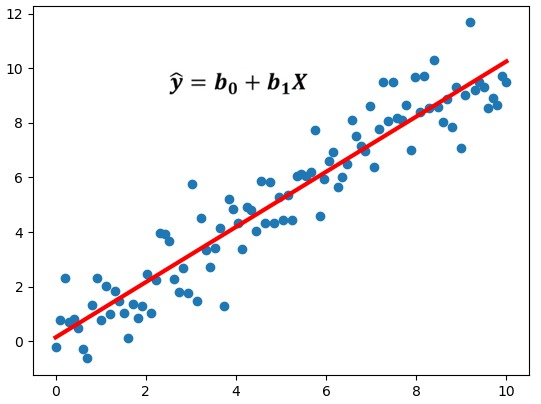

Img 1: Ejemplo de fenómeno lineal

Modelado de Relaciones:

La motivación fundamental de la regresión es modelar la relación entre variables. En muchos casos, existe la necesidad de entender cómo una variable dependiente cambia en función de una o más variables independientes. Por ejemplo, en la economía, podría ser necesario entender cómo las tasas de interés afectan el gasto del consumidor.

Predicción y Estimación: Los modelos de regresión también se utilizan para hacer predicciones y estimaciones. Dado un conjunto de datos históricos, los modelos de regresión pueden ayudar a predecir valores futuros de la variable dependiente en función de los valores de las variables independientes. Esto es especialmente útil en campos como la meteorología, la finanzas y el marketing.

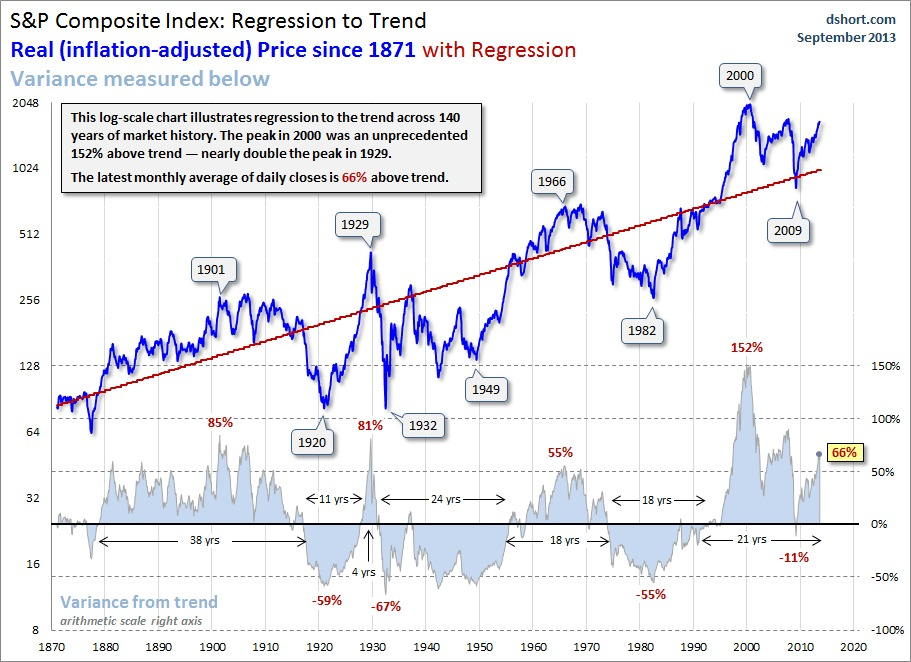

Img 2: Prediciendo la tendencia histórica del S&P

Control y Optimización: En algunos casos, se utilizan modelos de regresión para optimizar y controlar procesos. Por ejemplo, en la manufactura, los modelos de regresión pueden usarse para identificar las condiciones ideales que conducen a la máxima eficiencia o calidad del producto.

Validación de Teorías: En la investigación científica y social, los modelos de regresión pueden usarse para validar o refutar teorías existentes. Al comparar los resultados del modelo con las expectativas teóricas, se puede evaluar la validez de las hipótesis.

Gestión de Riesgos: Los modelos de regresión también se utilizan para evaluar riesgos y tomar decisiones informadas. En finanzas, por ejemplo, se pueden utilizar para evaluar el riesgo de inversión y la exposición a diferentes factores del mercado.

**Ejemplo**

El modelo CAPM (Capital Asset Pricing Model) es un modelo de valoración de activos financieros desarrollado por William Sharpe que permite estimar su rentabilidad esperada en función del riesgo sistemático. Su desarrollo está basado en diversas formulaciones de Harry Markowitz sobre la diversificación y la teoría moderna de Portfolio 1. El modelo CAPM es utilizado para calcular la rentabilidad que un inversionista debe exigir al realizar una inversión en un activo financiero en función del riesgo que está asumiendo 2. El modelo CAPM establece una relación lineal entre el rendimiento esperado de un activo y su riesgo sistemático, medido por su beta 1. La fórmula del modelo CAPM es la siguiente:

$E(r_i)=r_f+\beta_i*(E(r_m)-r_f)$

Donde:

$E(r_i)$ es la tasa de rentabilidad esperada de un activo concreto. $rf$ es la rentabilidad del activo sin riesgo. $\beta_i$ es la medida de la sensibilidad del activo respecto a su benchmark. $E(r_m)$ es la tasa de rentabilidad esperada del mercado en que cotiza el activo.

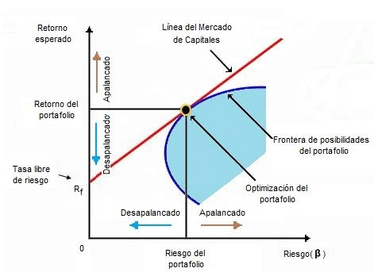

Img 3: Modelo CAMP para valoración de activos financieros

Análisis de Causa y Efecto: Los modelos de regresión pueden ayudar a establecer relaciones causa-efecto entre variables. Esto es útil para comprender cómo los cambios en una variable influyen en otras variables y viceversa.

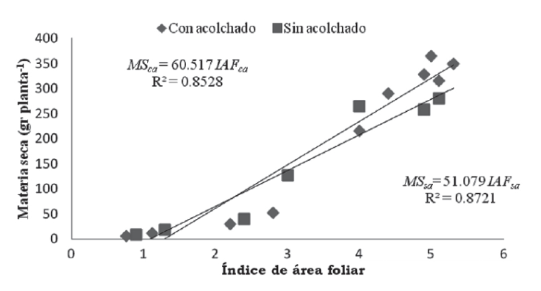

Img 4: Predicción de rendimientos de cultivos

En resumen, la motivación detrás de los métodos de regresión radica en la necesidad de entender, modelar, predecir y cuantificar las relaciones entre variables en una variedad de campos. Estos métodos permiten tomar decisiones informadas, realizar análisis profundos y obtener información valiosa a partir de los datos disponibles.

# Ejercicio de introducción.

## Lectura de datos

A continuación, cargaremos dos tablas de datos que contienen información sobre el precio del dolar, también conocida como tasa representativa del mercado, y otra con la información del precio del aguacate Hass tomada de una fuente gubernamental y de la página del SIPSA.

Los enlaces para acceder a información relacionada son:

https://www.agronet.gov.co/estadistica/Paginas/home.aspx?cod=11 https://www.bde.es/webbe/es/estadisticas/temas/tipos-cambio.html

```r
# Cargue y limpieza de datos.

dolar <- read.csv2("datasets/Tasa_de_Cambio_Representativa_del__Mercado_-Historico.csv") %>%
            clean_names()
hass <- read.xlsx("datasets/Hass_Precios_Historicos.xlsx") %>% clean_names()
```

## Creación de funciones.

Se programa una función de flextable que mejorará la impresión de tablas de resumen. Para usarla sólo bastará invocar la función ftable() al final de la sentencia (usando %>% tidyverse) o con el ftable() encapsular o encerrar la tabla que se quiere ajustar.

```r
# Funciones

## Función para crear flextable
ftable <- function(x) {
  x %>%
    flextable() %>%
    theme_vanilla() %>%
    color(part = "footer", color = "#666666") %>%
    color( part = "header", color = "#FFFFFF") %>%
    bg( part = "header", bg = "#2c7fb8") %>%
    fontsize(size = 11) %>%
    font(fontname = 'Calibri') %>%
    # Ajustes de ancho y tipo de alineación de las columnas
    set_table_properties(layout = "autofit") %>%
    # width(j=1, width = 3) %>%
    align(i = NULL, j = c(2:ncol(x)), align = "right", part = "all")
}
```

Como ejemplo del uso de la función:

*Sin flextable*

```r
dolar %>%
  head(5)
```

```
##      valor unidad vigenciadesde vigenciahasta
## 1 4,761.64    COP      22/12/22      22/12/22
## 2 4,781.28    COP      20/12/22      20/12/22
## 3 4,802.48    COP      17/12/22      19/12/22
## 4 4,836.24    COP      13/12/22      13/12/22
## 5 4,815.99    COP      10/12/22      12/12/22
```

*Con flextable*

```r
dolar %>%
  head(5) %>%
  ftable()
```

| valor | unidad | vigenciadesde | vigenciahasta |
| --- | --- | --- | --- |
| 4,761.64 | COP | 22/12/22 | 22/12/22 |
| 4,781.28 | COP | 20/12/22 | 20/12/22 |
| 4,802.48 | COP | 17/12/22 | 19/12/22 |
| 4,836.24 | COP | 13/12/22 | 13/12/22 |
| 4,815.99 | COP | 10/12/22 | 12/12/22 |

# DEPURACIÓN DE LOS DATOS

## Dolar

Como en todo proceso de análisis de datos, es necesario realizar una depuración y ajuste de los datos. Para este caso, fue necesario trabajar sobre la variable de la fecha y el valor.

```r
# Vamos a sacar un valor promedio de cada variable por mes
#Para el dolar vamos a tomar el campo vigenciadesde

dolar <- dolar %>%
    mutate(fecha = as.Date(vigenciadesde, format = "%d/%m/%y")) %>%
    mutate(mes = month(fecha), anio = year(fecha)) %>%
    mutate(valor = as.double(str_replace(valor,",",""))) %>%
    group_by(anio,mes) %>%
    summarise(precio_dolar = mean(valor), .groups = "drop")
```

A continuación se muestra una fracción de los datos depurados.

```r
dolar %>%
  datatable()
```

|  | anio | mes | precio_dolar |
| --- | --- | --- | --- |
| 1 | 1991 | 12 | 630.1190476190476 |
| 2 | 1992 | 1 | 644.5977272727273 |
| 3 | 1992 | 2 | 635.5819047619048 |
| 4 | 1992 | 3 | 640.5225 |
| 5 | 1992 | 4 | 649.1635 |
| 6 | 1992 | 5 | 660.0285714285715 |
| 7 | 1992 | 6 | 676.4211111111111 |
| 8 | 1992 | 7 | 704.5004545454545 |
| 9 | 1992 | 8 | 693.7173684210526 |
| 10 | 1992 | 9 | 697.1063636363637 |

[output cut: 371 more lines]

## Aguacate

```r
hass %>%
  head(5) %>%
  ftable()
```

| mercado | producto | fecha | precio_kg |
| --- | --- | --- | --- |
| Bogotá, D.C., Corabastos | Aguacate hass (Semanal \| Mensual) | Sabado, Junio 23 de 2012 | 3,483 |
| Bogotá, D.C., Corabastos | Aguacate hass (Semanal \| Mensual) | Sabado, Junio 30 de 2012 | 3,459 |
| Bogotá, D.C., Corabastos | Aguacate hass (Semanal \| Mensual) | Sabado, Julio 7 de 2012 | 3,478 |
| Bogotá, D.C., Corabastos | Aguacate hass (Semanal \| Mensual) | Sabado, Julio 14 de 2012 | 3,493 |
| Bogotá, D.C., Corabastos | Aguacate hass (Semanal \| Mensual) | Sabado, Julio 21 de 2012 | 3,470 |

```r
# 🖇️ Se genera el vector de meses para usarlo más abajo con la función match.
meses <- c("Enero", "Febrero", "Marzo", "Abril", "Mayo",
           "Junio", "Julio", "Agosto", "Septiembre", "Octubre",
           "Noviembre", "Diciembre")

hass <- hass %>%
      # Otra forma de sacar el anio.
      #mutate(anio = substring(fecha,nchar(fecha)-4,nchar(fecha))) %>%
      #mutate(espacio = grepl(", ",fecha))
      mutate(mes = sapply(strsplit(fecha, " "), "[", 2),
             anio = sapply(strsplit(fecha, " "), "[", 5)) %>%
      mutate(anio = as.double(anio)) %>%
      # 🖇 Se utiliza la función match con el vector meses.
      mutate(mes = match(mes,meses)) %>%
      group_by(anio,mes) %>%
      summarise(precio_aguacate_kg = mean(precio_kg), .groups = "drop")
```

```r
hass %>% datatable()
```

|  | anio | mes | precio_aguacate_kg |
| --- | --- | --- | --- |
| 1 | 2012 | 6 | 3471 |
| 2 | 2012 | 7 | 3459.5 |
| 3 | 2012 | 8 | 3543.5 |
| 4 | 2012 | 9 | 3792 |
| 5 | 2012 | 10 | 3661.25 |
| 6 | 2012 | 11 | 3580.5 |
| 7 | 2012 | 12 | 2946 |
| 8 | 2013 | 1 | 2776.25 |
| 9 | 2013 | 2 | 2731.75 |
| 10 | 2013 | 3 | 3312.8 |

[output cut: 124 more lines]

# Datos unidos

```r
hass_dolar <- dolar %>%
  right_join(hass, by = c("mes","anio"))

hass_dolar %>%
  head(5) %>%
  ftable()
```

| anio | mes | precio_dolar | precio_aguacate_kg |
| --- | --- | --- | --- |
| 2,012 | 6 | 1,792.232 | 3,471.00 |
| 2,012 | 7 | 1,785.141 | 3,459.50 |
| 2,012 | 8 | 1,806.341 | 3,543.50 |
| 2,012 | 9 | 1,801.948 | 3,792.00 |
| 2,012 | 10 | 1,805.674 | 3,661.25 |

# Regresión Lineal con los datos.

## Gráfico de dispersión

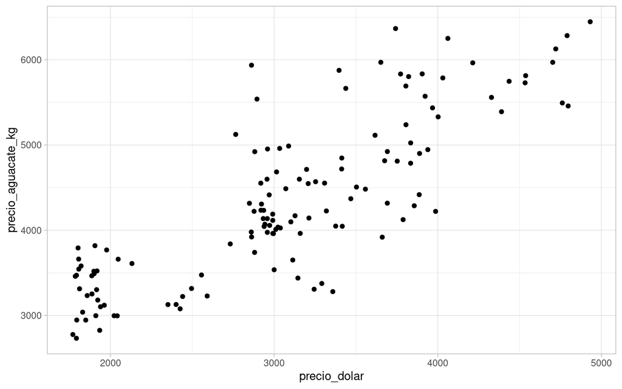

```r
hass_dolar %>%
  ggplot(aes(x= precio_dolar, y= precio_aguacate_kg )) +
  geom_point()+ theme_light()
```

Cómo se puede notar uno intuye que hay alguna relación entre ambas variables en la medida en que parece suceder que cuando el precio del dólar aumenta, también lo hace el precio de aguacate. La relación no es perfecta pues no vemos una curva suave que sea capaz de pasar por todos los puntos, más bien debemos reconocer que hay ciertas variaciones en el proceso. Estas variaciones pueden deberse a factores no contemplados por el modelo, después de todo no podemos esperar que el precio del aguacate dependa exclusivamente del precio del dólar.

## Generando un modelo súper simplificado

Ahora vamos a generar el modelo más sencillo que podamos imaginar para predecir el precio del aguacate, al cual llamaremos un modelo ingenuo. La razón del apelativo es que el modelo “ingenuamente” supondrá que es posible predecir el precio que tendrá el aguacate con el promedio histórico.

La siguiente gráfica muestra la linea horizontal que simboliza el promedio histórico del precio del aguacate. También debe notar que predecir basado en esta línea es despreciar cualquier aporte de la variable precio del dólar en la predicción, es decir, es un modelo que no explota la relación (sea esta débil o sea esta fuerte) entre el precio del aguacate y su variable explicativa precio del dólar.

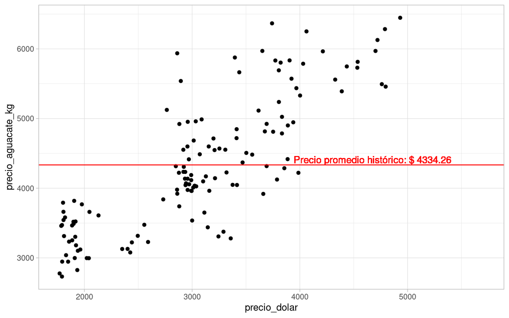

```r
hass_dolar %>%
  ggplot(aes(x= precio_dolar, y= precio_aguacate_kg )) +
  geom_point()+
  geom_hline(yintercept = mean(hass_dolar$precio_aguacate_kg), color = "red")+
  geom_text(aes(x= 5700, y = mean(hass_dolar$precio_aguacate_kg),
                label = paste("Precio promedio histórico: $",
                              round(mean(hass_dolar$precio_aguacate_kg), 2))),
    hjust = 1.2, vjust = -0.2, color = "red"
  ) +
  theme_light()
```

Observe que el modelo ingenuo no sería tan inadecuado en dos circunstancias:

- Si los datos se encuentran muy cercanos al precio histórico de manera consistente sin importar en que valor del precio del dólar me posicione. Lo que vendría a indicar un escenario donde moverme a lo largo de diferentes valores del precio del dólar no genera ningún patrón de distanciamiento frente al valor histórico de referencia.
- Si los datos del precio del aguacate se alejan de la línea histórica de referencia pero el precio del dólar tampoco puede seguirlos, es decir, si la relación entre precio del dólar y precio del aguacate se parece a una nube de puntos sin ningún patrón o tendencia evidente. En este caso cualquier cosa que supongamos de la relación entre precio de dólar y precio del aguacate será producto de nuestra imaginación :)

En estos dos escenarios es mejor retener el modelo ingenuo a falta de una variable que de verdad explique lo que pasa con el precio del aguacate.

Ahora bien, ninguno de los dos escenarios anteriores parece ser el nuestro, más bien acá se nota que el precio del dólar si está acompasado con el precio del aguacate. Sin embargo antes de entrar en la búsqueda de esas relaciones es importante notar dos cosas:

- El modelo ingenuo es mi modelo de referencia, esto significa que si un modelo predictivo construido para predecir el precio del aguacate es mejor, lo tendrá que ser respecto a este modelo ingenuo.
- Es posible medir el desajuste actual de mi modelo ingenuo tomando la distancia de cada punto a la recta horizontal de promedio histórico, esto es:

Sea $e_i = y_i - \bar{y}$ las diferencia entre el dato del precio de aguacate $y_i$ y el promedio histórico $\bar{y}$. Como tengo muchas diferencias, será necesario definir una métrica resumen, por conveniencia elijamos la suma de los cuadrados de las diferencias, debido a que si sumamos las diferencias, éstas se me compensarán, pues diferencias negativas cancelarán las positivas, y no quiero esto. Más bien me interesa que ambas sumen a mi medida de desajuste. Llamemos a esta medida la suma de cuadrados del error:

$$SCE_{\text{ingenuo}} =
\sum^{n}_{i=1}e_i²=\sum^{n}_{i=1}(y_i - \bar{y})²$$
En la definición de la cantidad quisimos usar el subíndice “ingenuo” para nombra al SCE, esto con el fin de hacer énfasis que tal métrica se asocia al modelo, si el modelo cambia a otro tipo de modelo el SCE cambiará también: será la distancia de cada $y_i$ a la curva definida por el otro modelo. Veremos esto más adelante. No obstante ya podemos sacar nuestras primeras conclusiones:

1. Entre más grandes sean cada una de las distancias $e_i$ individuales, más grande será SCE.
2. Todas las distancias contribuyen con igual importancia al SCE, excepto en lo que se refiere a su magnitud no hay porque pensar que un distanciamiento de $u$ unidades se más importante que otro de las mismas $u$ unidades. Esto puede ser obvio, pero no lo es cuando queremos castigar más las distancias que se dan en la zona central del gráfico que las que se dan en los extremos del gráfico, por ejemplo.
3. El SCE es sensible a la cantidad de datos, razón por la cual entre más datos (más grande sea n), más grande será SCE. Esto dificulta seriamente la posibilidad de comparar modelos que fueron calculados sobre una cantidad distinta de puntos.

De acuerdo con lo anterior modifiquemos un poco nuestra definición de desajuste, así:

$$MSE_{\text{ingenuo}}
= \frac{1}{n}\sum^{n}_{i=1}(y_i - \bar{y})²$$

Es decir, nuestra medida de desajuste será el promedio de la suma de las diferencias cuadradas de cada dato $y_i$ respecto a su media $\bar{y}$, dicho de otra manera la varianza de la variable $Y$ a predecir!!!!

A continuación invitamos al estudiante a calcular la varianza de la variable a predecir, es decir, el desajuste del modelo ingenuo.

```r
# En esta sección el estudiante desarrollará los cálculos.

# 💡 Recordemos que la varianza de los residuales respecto del modelo ingenuo, es la misma varianza de la variable a predecir.
```

Observe el siguiente gráfico donde además hemos pintado las distancias que hay entre cada dato $y_i$ observado y el promedio histórico $\bar{y}$:

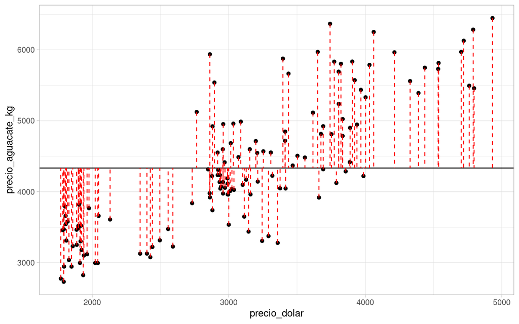

```r
hass_dolar %>%
  ggplot(aes(x= precio_dolar, y= precio_aguacate_kg )) +
  geom_point()+
  geom_hline(yintercept = mean(hass_dolar$precio_aguacate_kg))+
  geom_segment(aes(xend=precio_dolar, yend=mean(precio_aguacate_kg)),
               col='red', lty='dashed')+
  theme_light()
```

## Modelo

Este es el momento de comenzar a usar la información extra con la que contamos, esto es, el precio del dólar, el cual se convertirá en una variable predictora del precio del aguacate. En estadística no hay una única forma de hacer esto, pero lo usual es partir de especificaciones muy sencillas. Veamos:

Sea $Y$ el precio del aguacate y sea $X$ el precio del dólar. Investiguemos si este modelo sencillo nos funciona:

$$y = \beta_{0} + \beta_{1} * x + e \text{
con } e \text{~}N(0, \sigma^2)$$
Expliquemos esto que implica haciendo ciertas anotaciones de gran relevancia práctica para entender cómo los estadísticos piensan al momento de plantear modelos:

Observación genial 1:

Para un x fijo, es decir un x dado, es posible calcular el valor de $y$ con el modelo anterior, donde tácitamente estamos diciendo que valor de $y$ dependerá de $x$ en forma exacta excepto por una perturbación aleatoria $e$ que representará la parte del valor de $y$ que no puede ser capturada por el término $\beta_{0} + \beta_{1} * x$.

¿Cuándo sucederá que el valor de $y$ pueda ser exactamente capturado por el término $\beta_{0} + \beta_{1} * x$? Cuando $y$ dependa en forma lineal exacta del valor de $x$. Esta es una condición demasiado fuerte que rara vez ocurre en la práctica, por eso agregamos la perturbación $e$ como una forma de modelar la **incertidumbre** en la determinación de $y$ dado un valor de $x$. Esto no soluciona todos los problemas pero ayuda a obtener un modelo relativamente más realista.

Observación genial 2:

La perturbación $e$ puede recibir varios nombres en estadística, la encontrarás nombrada como: perturbación, choque, error, o residual. Lo importante no es el nombre que reciba, sino las condiciones que vamos a suponer sobre sus valores.

En particular no vamos a exigir que $e$ tenga valores predecibles, muy al contrario vamos a exigir que sea un valor aleatorio, precisamente porque está modelando incertidumbre. Pero esto no implica que no podamos poner ciertas condiciones sobre el **tipo de aleatoriedad deseada para** $e$. En este caso supondremos que $e$ se distribuye como una variable aleatoria normal con media $\mu=0$ y desviación estándar $\sigma$.

Observación genial 3:

¿Por qué suponemos normalidad para $e$? Porque si $e$ es en efecto una especie de componente incierto en el valor de $y$, entonces muy seguramente será la suma de muchos efectos independientes que lo están provocando. En nuestro contexto estos efectos inciertos pueden ser:

- $F_1$: Cambios en la productividad de los cultivos.
- $F_2$: Condiciones climatológicas.
- $F_3$: Precios de los insumos agrícolas.
- $F_4$: Capacidad de negociación de los productores.
- $F_5$: Presencia o no de subsidios estatales.
- $F_6$: Precios de productos complementarios o sustitutos.

.

.

.

- $F_k$: precio de la gasolina.

Y un gran etcétera.

Es decir, existen innumerables factores, distintos al precio del dólar que impiden que el precio del aguacate pueda ser determinado de forma exacta sólo por observar el valor del dólar. En estadística se ha estudiado que cuando no estamos midiendo los demás factores que afectan el valor de una variable, y dejamos que estos contribuyan de forma desacoplada e independiente a dicho valor, el efecto general $e$ que resume el efecto global de todos los factores a la vez, suele comportarse bajo la distribución normal sencillamente porque hay un teorema en matemáticas, conocido como el Teorema del Límite Central que básicamente así lo garantiza, al postular que: *la suma de* $k$ *efectos aleatorios independientes tiende a adoptar el comportamiento normal conforme la cantidad k de efectos crece*.

Es importante destacar que el Teorema del Límite Central tiene algunas condiciones y suposiciones, como la independencia de las variables aleatorias y que la suma debe efectuarse sobre una cantidad $k$ de ellas suficientemente grande. Sin embargo, es uno de los conceptos fundamentales en estadística y es ampliamente utilizado en la teoría y la práctica de esta disciplina.

Observación para nada genial 4:

Excepto por el componente aleatorio $e$, el modelo restringe la relación de $Y$ y $X$ al universo de relaciones lineales. Existirá una posible relación por cada par de valores $\beta_0$ y $\beta_1$ que decidamos elegir. Pero por más que nos esforcemos en modificarlos siempre conducirán a relaciones representadas por líneas rectas, de ahí que el modelo asuma el nombre de regresión lineal.

Observación genial final:

Son los datos observados para cada valor de $y$ y $x$ los que nos deben informar sobre el par de valores $\beta_0$ y $\beta_1$ que crean la relación lineal que mejor representa nuestra nube de puntos, pero de nada sirven los valores observados si no definimos una métrica que nos informe sobre la calidad del ajuste. ¿Cómo decidimos el par de parámetros si no tenemos un criterio para poder saber cuál es el mejor modelo?

Para salir de este embrollo reconozcamos que nunca en un problema real sujeto a incertidumbre una recta pasará exactamente por todos los puntos, razón por la cual aparecerán componentes de error $e_i$ por cada $y_i$ y $x_i$ observado. Pasó con el modelo ingenuo y pasará de nuevo acá. La idea es entonces reducir la magnitud de estos errores al mínimo posible y el par de valores $\beta_1$ y $\beta_2$ que así lo logren será nuestra elección óptima de cara al objetivo de minimización del error.

Otro criterio de ajuste que se podría usar es el de maximizar la probabilidad de ocurrencia de los valores observados bajo el supuesto de que el modelo usa valores $\beta_0$ y $\beta_1$ previamente especificados. De esta manera si un par de valores hace menos probable haber obtenido nuestros datos observados deberán descartarse.

¿Pero cómo podemos medir la probabilidad de ocurrencia de nuestros datos observados una vez damos valores específicos para los betas? Esta es una cuestión que se tratará más adelante cuando discutamos los **métodos de estimación de parámetros**, nombre con el que se conoce al procedimiento estadístico encaminado a elegir los mejores betas para un conjunto de datos observados.

Por lo pronto vamos a ejemplificar un posible modelo ajustado usando valores $\beta_0=700$ y $\beta_1 = 1.2$. Hemos elegido estos valores por simple inspección visual así que no esperamos que sean óptimos en ningún sentido, veamos:

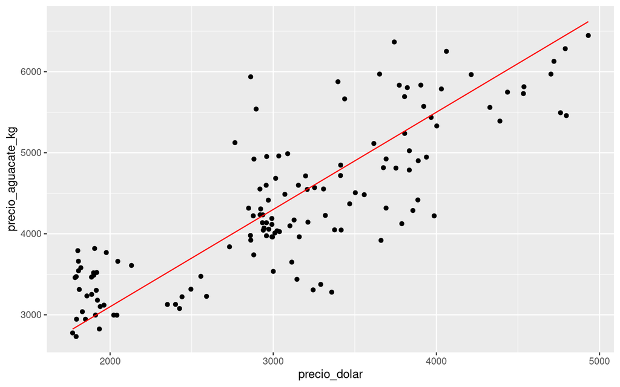

```r
# Calculamos las predicciones de y usando el modelo
b0 = 700
b1 = 1.2
x= hass_dolar$precio_dolar
y_pred = b0 + b1*x

hass_dolar %>%
  ggplot(aes(x= precio_dolar, y= precio_aguacate_kg ))+
  geom_point() +
  geom_line( aes( x= x, y = y_pred), col = "red")
```

```r
# lm(formula, data, subset, weights, na.action,
#    method = "qr", model = TRUE, x = FALSE, y = FALSE, qr = TRUE,
#    singular.ok = TRUE, contrasts = NULL, offset, ...)


mod1 <- hass_dolar %>% lm(precio_aguacate_kg ~ precio_dolar,.)

summary(mod1)
```

```
##
## Call:
## lm(formula = precio_aguacate_kg ~ precio_dolar, data = .)
##
## Residuals:
##      Min       1Q   Median       3Q      Max
## -1330.83  -314.21   -22.81   284.05  1795.79
##
## Coefficients:
##               Estimate Std. Error t value Pr(>|t|)
## (Intercept)  1.437e+03  1.789e+02   8.032 4.69e-13 ***
## precio_dolar 9.450e-01  5.634e-02  16.773  < 2e-16 ***
## ---
## Signif. codes:  0 '***' 0.001 '**' 0.01 '*' 0.05 '.' 0.1 ' ' 1
##
## Residual standard error: 537.1 on 132 degrees of freedom
## Multiple R-squared:  0.6806, Adjusted R-squared:  0.6782
## F-statistic: 281.3 on 1 and 132 DF,  p-value: < 2.2e-16
```

```r
# Generando el modelo con R Base sería así:
# mod1 <- lm(promedio_aguacate_kg ~ promedio_dolar, hass_dolar)
```

¿Cuál es la representación funcional del modelo?

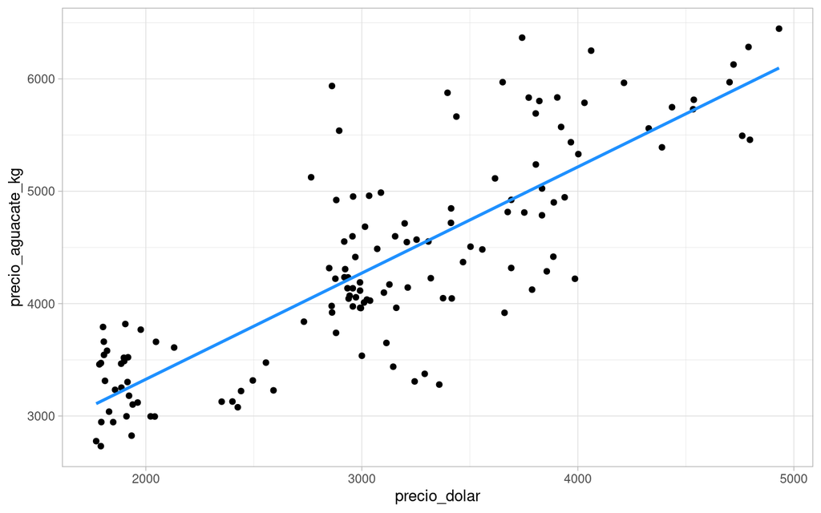

```r
hass_dolar %>%
  ggplot(aes(x= precio_dolar, y= precio_aguacate_kg )) +
  geom_point()+ theme_light()+
  geom_smooth(method='lm', formula=y~x, se=FALSE, col='dodgerblue1')
```

# Varianza de los residuales del modelo

# Obteniendo los coeficientes.

```r
mod1$coefficients
```

```
##  (Intercept) precio_dolar
## 1436.6790256    0.9449775
```

# Valores ajustados - Fitted values.

```r
mod1$fitted.values %>%
  head(20)
```

```
##        1        2        3        4        5        6        7        8
## 3130.297 3123.597 3143.631 3139.479 3143.000 3157.035 3131.911 3109.503
##        9       10       11       12       13       14       15       16
## 3129.884 3148.096 3165.846 3183.871 3242.079 3230.649 3237.020 3248.871
##       17       18       19       20
## 3218.826 3253.241 3264.442 3291.015
```

# Residuales

```r
mod1$residuals %>%
  head(20)
```

```
##          1          2          3          4          5          6          7
##  340.70260  335.90285  399.86948  652.52072  518.25021  423.46463 -185.91095
##          8          9         10         11         12         13         14
## -333.25250 -398.13417  164.70412 -127.34649 -238.37054 -245.07936  287.60071
##         15         16         17         18         19         20
##  581.57961  273.37874  246.42423  -73.04054 -439.44215 -171.26527
```

```r
# Los valores ajustados y los residuales también se pueden recuperar usando las funciones fitted( ) y residuals( ). Consulte la ayuda de estas funciones para conocer otros detalles.
```

Calcular la varianza de los residuales.

```r
# En esta sección el estudiante desarrollará los cálculos.
```

# Porcentaje de variabilidad no explicada por el modelo.

```r
# En esta sección el estudiante desarrollará los cálculos.
```

# Diagrama de dispersión con los puntos originales

## Creación de la columna de predicción

En este chunk trabajamos con el modo de escritura Tidyverse, aunque se muestra cómo sería con R base.

```r
#hass_dolar$predicciones <- predict(mod1)

hass_dolar <- hass_dolar %>%
                mutate(predicciones = predict(mod1))
```

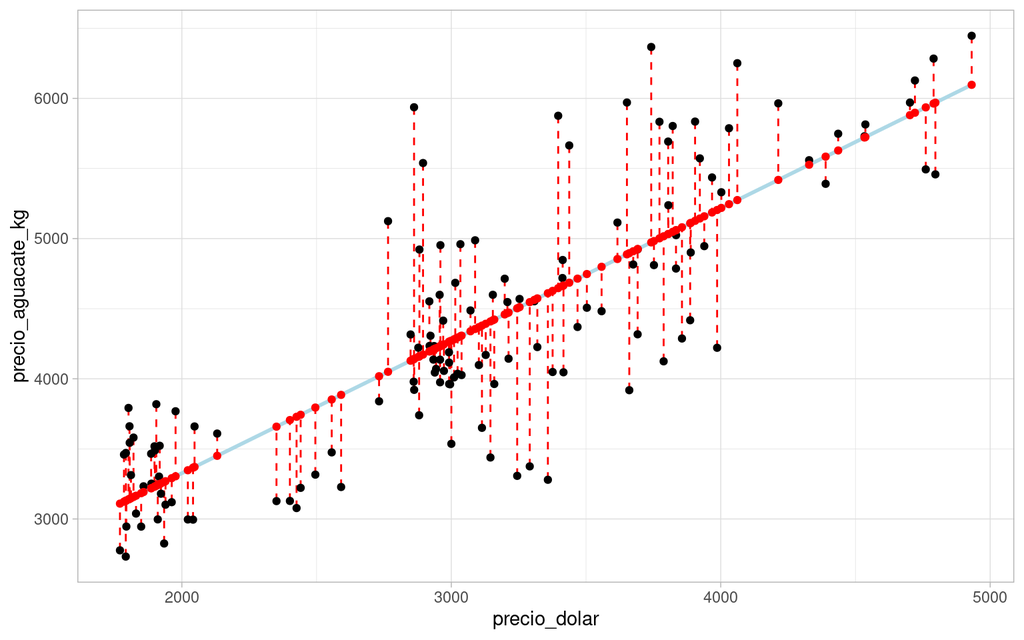

```r
hass_dolar %>%
ggplot(aes(x = precio_dolar, y = precio_aguacate_kg)) +
  geom_smooth(method = "lm", se = FALSE, color="lightblue") +
  geom_segment(aes(xend=precio_dolar, yend=predicciones),
               col='red', lty='dashed') +
  geom_point() +
  geom_point(aes(y=predicciones), col='red') +
  theme_light()
```

```r
#Con R Base
# ggplot(datos, aes(x=Edad, y=Resistencia)) +
#   geom_smooth(method="lm", se=FALSE, color="lightgrey") +
#   geom_segment(aes(xend=Edad, yend=predicciones), col='red', lty='dashed') +
#   geom_point() +
#   geom_point(aes(y=predicciones), col='red') +
#   theme_light()
```

# REVISIÓN BÁSICA DE CONCEPTOS - Simulación.

Vamos a simular un modelo de regresión cuya especificación funcional es la siguiente:

$$y = \beta_0 + \beta_1 * x + e$$

Con $e \text{~} N(0,\sigma^2)$

Como se puede notar, todo modelo teorico se compone de dos términos:

1. El valor E(y|x)= E_y_x (valor esperado de y dado x)
2. El componente aleatorio también llamado error.

Aunque en el modelo anterior hemos elegido una estructura lineal para representar E(y|x) en realidad podemos elegir cualquier otra estructura alternativa, siempre que respetemos la linealidad en los betas.

```r
bo = 2
b1_1 = 3
b1_2 = 0.5
x <- seq(1,10)

# Estructura para el valor esperado de y dado x ()
# Esta estructura admitiría otras formas funcionales

# El valor esperado es deterministico.
E_y_x_1 <- bo + b1_1 * x

E_y_x_2 <- bo + b1_1 * x + b1_2 * x^2


# el valor observado o valor real, es aleatorio.



y_obs_1 <- E_y_x_1 + rnorm(10, 0, 4)

y_obs_2 <- E_y_x_2 + rnorm(10, 0, 4)

datos_simulados <- data.frame(
  x = x,
  x_2 = x^2,
  E_y_x_1 = E_y_x_1,
  E_y_x_2 = E_y_x_2,
  y_obs_1 = y_obs_1,
  y_obs_2 = y_obs_2,
  y_pred_1 = predict(lm(y_obs_1 ~ x)),
  y_pred_2 = predict(lm(y_obs_2 ~ x+ x^2)))
```

# Dibujamos un gráfico de dispersión

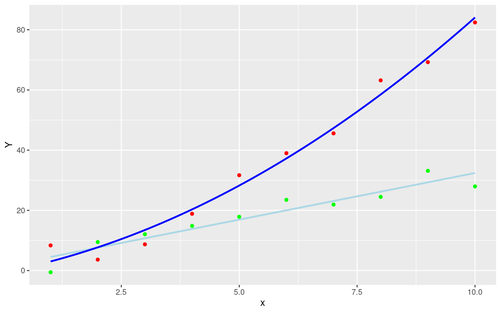

```r
datos_simulados %>%
ggplot(aes(x = x, y = y_obs_1)) +
  geom_smooth(method = "lm", formula = y~x, se = FALSE, color="lightblue") +
  geom_point(col = "green")+
  geom_point(aes(y=y_obs_2), col='red')+
  geom_smooth(method="lm", se= FALSE ,formula=y_obs_2~poly(x, 2),color = "blue")+
  ylab("Y")
```

# DISCUTIENDO SOBRE LA LINEALIDAD DE LOS BETAS

En esta sección vamos a aclarar el asunto de que los BETAS sean lineales.

La linealidad en este contexto hace referencia a que no tengan potencias y que los **coeficientes sean independendientes entre ellos**.

Supongamos un modelo con coeficientes repetidos.

$$E(y|x) = \beta_0 + \alpha * x + \alpha *
x^2$$

Debemos factorizarlos para evitar estimarlos por separado y producir inconsistencias,esto debido a que ambos alpha (coeficientes) son dependientes.Es decir, reescribimos:

$$E(y|x) = \beta_0 + \alpha (x + x^2)$$

Donde el componente x + x² será el vector de valores de la variable predictora, que puede pensarse como una variable nueva:

$$\tilde{x} = x + x^2$$
Y por lo tanto pensar al modelo como:

$$E(y|x) = \beta_0 + \alpha *
\tilde{x}$$
Esta transformación garantiza la creación de un nuevo modelo lineal respecto a $\beta_0$ y $\alpha$.

Es importante anotar que el dataframe que alimentará el modelo deberá tener computada la variable auxiliar $\tilde{x}$, la cual debe ser pasada a la función encargada de estimar parámetros.

Esto corresponde a crear una nueva variable con los cálculos mencionados $\tilde{x} = x + x^2$. Sin embargo, para graficar es conveniente usar la variable original.

```r
# Se define una semilla para generar los aleatorios.
set.seed(77)

alpha <- 0.7

E_y_x_3 = bo + alpha * (x + x^2)
y_obs_3 = E_y_x_3 + rnorm(10, 0, 4)

x_auxiliar = x + x^2

datos_simulados_2 <- data.frame(
  x = x,
  x_2 = x^2,
  x_auxiliar = x_auxiliar,
  E_y_x_3 = E_y_x_3,
  y_obs_3 =  y_obs_3,
  y_pred_3_1 = predict(lm(y_obs_3 ~ poly(x, 2))),
  y_pred_3_2 = predict(lm(y_obs_3 ~ x_auxiliar )))


modelo1a <-  lm(y_obs_3 ~ poly(x, 2))
modelo1b <-  lm(y_obs_3 ~ poly(x, 2, raw = TRUE))
modelo2 <-  lm(y_obs_3 ~ x_auxiliar )
```

Notese que los coeficientes arrojados por el modelo1a al invocar la función poly sin parámetro de raw=TRUE, no son atribuibles o no están asociados a los términos $1,x,x^2$, es decir, **No es válido escribir**:

$$E(y|x)= 34.41 * 1 + 76.82 * x + 16.74 *
x^2$$
Esta ecuación no sería válida porque al remplazar para $x=5$ se obtiene $E(y|5)=$ 836.91, mientras que al remplazar en el modelo con el parámetro raw = TRUE, se obtendría: $E(y|5)=$ 24.35.

Observe que para el valor $x=5$ los valores observados de $y$ están cercanos a 24 por lo que una predicción arrojando un valor cercano a 836, está claramente desfasada. Observe el gráfico más abajo para comprender lo explicado.

Esto se debe a que los coeficientes anclados al modelo_1a están diseñados para ser usados sobre la siguiente base de polinomios ortogonales:

- $P_1(x)= a$
- $P_2(x)=m*x - c$
- $P_3(x)= k_1 + k_2 *x + k_3 * x ^2$

Donde $a,m,c,k_1,k_2,k_3$ son parámetros estimados que lamentablemente no están siendo arrojados por el modelo.

A continuación se muestra el resumen de cada uno de los modelos, utilizando la función summary().

```r
summary(modelo1a)
```

```
##
## Call:
## lm(formula = y_obs_3 ~ poly(x, 2))
##
## Residuals:
##     Min      1Q  Median      3Q     Max
## -5.4051 -2.0000  0.2405  2.8394  3.5594
##
## Coefficients:
##             Estimate Std. Error t value Pr(>|t|)
## (Intercept)   34.407      1.143  30.108 1.15e-08 ***
## poly(x, 2)1   76.820      3.614  21.257 1.28e-07 ***
## poly(x, 2)2   16.736      3.614   4.631  0.00239 **
## ---
## Signif. codes:  0 '***' 0.001 '**' 0.01 '*' 0.05 '.' 0.1 ' ' 1
##
## Residual standard error: 3.614 on 7 degrees of freedom
## Multiple R-squared:  0.9854, Adjusted R-squared:  0.9813
## F-statistic: 236.7 on 2 and 7 DF,  p-value: 3.736e-07
```

```r
summary(modelo1b)
```

```
##
## Call:
## lm(formula = y_obs_3 ~ poly(x, 2, raw = TRUE))
##
## Residuals:
##     Min      1Q  Median      3Q     Max
## -5.4051 -2.0000  0.2405  2.8394  3.5594
##
## Coefficients:
##                         Estimate Std. Error t value Pr(>|t|)
## (Intercept)               3.9133     4.2503   0.921  0.38783
## poly(x, 2, raw = TRUE)1   0.4458     1.7751   0.251  0.80890
## poly(x, 2, raw = TRUE)2   0.7283     0.1573   4.631  0.00239 **
## ---
## Signif. codes:  0 '***' 0.001 '**' 0.01 '*' 0.05 '.' 0.1 ' ' 1
##
## Residual standard error: 3.614 on 7 degrees of freedom
## Multiple R-squared:  0.9854, Adjusted R-squared:  0.9813
## F-statistic: 236.7 on 2 and 7 DF,  p-value: 3.736e-07
```

```r
summary(modelo2)
```

```
##
## Call:
## lm(formula = y_obs_3 ~ x_auxiliar)
##
## Residuals:
##     Min      1Q  Median      3Q     Max
## -5.5584 -2.0443  0.1458  2.8929  3.7758
##
## Coefficients:
##             Estimate Std. Error t value Pr(>|t|)
## (Intercept)  3.35135    1.71306   1.956   0.0861 .
## x_auxiliar   0.70580    0.03039  23.222 1.26e-08 ***
## ---
## Signif. codes:  0 '***' 0.001 '**' 0.01 '*' 0.05 '.' 0.1 ' ' 1
##
## Residual standard error: 3.386 on 8 degrees of freedom
## Multiple R-squared:  0.9854, Adjusted R-squared:  0.9836
## F-statistic: 539.3 on 1 and 8 DF,  p-value: 1.256e-08
```

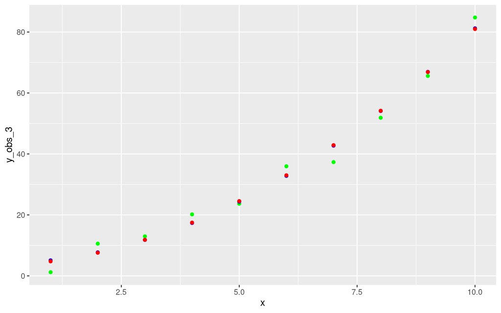

```r
datos_simulados_2 %>%
  ggplot(aes(x = x , y = y_obs_3))+
  geom_point(col = 'green')+
  geom_point(aes(y = y_pred_3_1), col = 'blue')+
  geom_point(aes(y = y_pred_3_2), col = 'red')
```

# ESTIMACIÓN DE PARÁMETROS

## Por máxima verosimilitud.

## Por mínimos cuadrados.

```r
n <- 1000

vector_x <- c(1: n )
sigma <- 4
beta_0 <- 2
beta_1 <- 0.5

# Esperada de y dado x
E_y_x <- beta_0 + (beta_1 * vector_x )

print(E_y_x)
```

```
##    [1]   2.5   3.0   3.5   4.0   4.5   5.0   5.5   6.0   6.5   7.0   7.5   8.0
##   [13]   8.5   9.0   9.5  10.0  10.5  11.0  11.5  12.0  12.5  13.0  13.5  14.0
##   [25]  14.5  15.0  15.5  16.0  16.5  17.0  17.5  18.0  18.5  19.0  19.5  20.0
##   [37]  20.5  21.0  21.5  22.0  22.5  23.0  23.5  24.0  24.5  25.0  25.5  26.0
##   [49]  26.5  27.0  27.5  28.0  28.5  29.0  29.5  30.0  30.5  31.0  31.5  32.0
##   [61]  32.5  33.0  33.5  34.0  34.5  35.0  35.5  36.0  36.5  37.0  37.5  38.0
##   [73]  38.5  39.0  39.5  40.0  40.5  41.0  41.5  42.0  42.5  43.0  43.5  44.0
##   [85]  44.5  45.0  45.5  46.0  46.5  47.0  47.5  48.0  48.5  49.0  49.5  50.0
##   [97]  50.5  51.0  51.5  52.0  52.5  53.0  53.5  54.0  54.5  55.0  55.5  56.0
##  [109]  56.5  57.0  57.5  58.0  58.5  59.0  59.5  60.0  60.5  61.0  61.5  62.0
##  [121]  62.5  63.0  63.5  64.0  64.5  65.0  65.5  66.0  66.5  67.0  67.5  68.0
##  [133]  68.5  69.0  69.5  70.0  70.5  71.0  71.5  72.0  72.5  73.0  73.5  74.0
##  [145]  74.5  75.0  75.5  76.0  76.5  77.0  77.5  78.0  78.5  79.0  79.5  80.0
##  [157]  80.5  81.0  81.5  82.0  82.5  83.0  83.5  84.0  84.5  85.0  85.5  86.0
##  [169]  86.5  87.0  87.5  88.0  88.5  89.0  89.5  90.0  90.5  91.0  91.5  92.0
```

[output cut: 69 more lines]

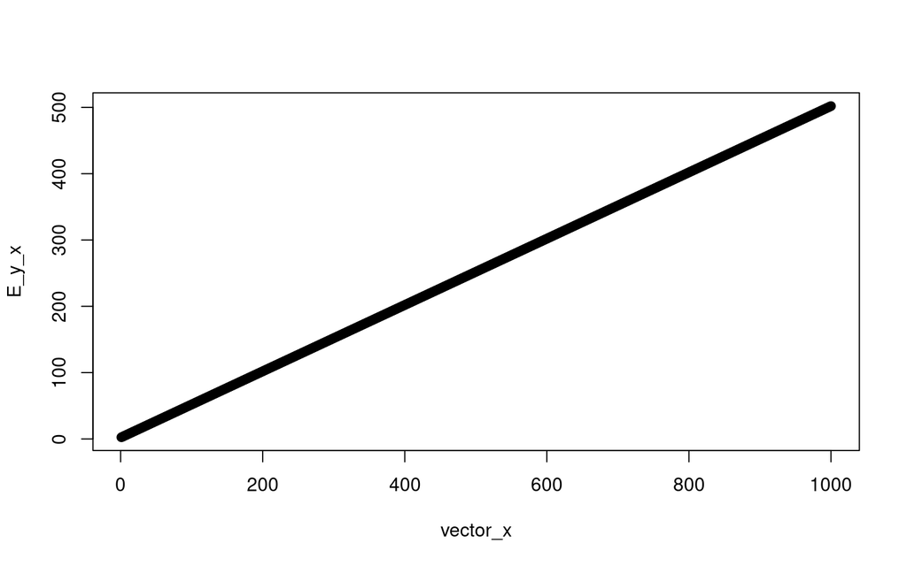

```r
plot(vector_x,E_y_x)
```

```r
error <- rnorm(n = n, mean = 0, sd = sigma)

y_observado <- beta_0 + (beta_1 * vector_x ) + error

print(y_observado)
```

```
##    [1]  -9.265541   2.028646   2.937660   3.869384   5.619264   7.360592
##    [7]   9.597181  14.429291   7.118537  10.652279   6.483102  14.077727
##   [13]  15.625079   5.484622   3.383127  10.543646   7.664401   5.361710
##   [19]  18.823746  17.160776   3.050258  10.796101  12.281348  11.000155
##   [25]  15.074887  12.802274  16.139696  15.649304  16.824517  20.596477
##   [31]  17.512477  15.875106  15.660199  17.834672  23.038678  19.382678
##   [37]  16.682756  23.669010  23.053954  24.196648  17.280075  26.547745
##   [43]  32.843871  26.012656  15.428101  16.873824  24.947705  22.189917
##   [49]  32.810645  22.008560  29.094688  28.106801  24.494048  29.035585
##   [55]  28.843687  31.690343  28.804476  29.121890  32.188607  39.387922
##   [61]  25.946999  31.670173  35.291761  35.089666  33.482570  44.393269
##   [67]  34.647942  36.202546  27.516022  40.678747  40.505934  37.733686
##   [73]  36.485893  38.358421  39.127831  41.895726  41.022360  43.869311
##   [79]  41.487409  33.293631  46.007014  46.340168  43.307650  30.361798
##   [85]  38.446858  46.009403  43.606182  49.908762  56.240348  46.670516
```

[output cut: 152 more lines]

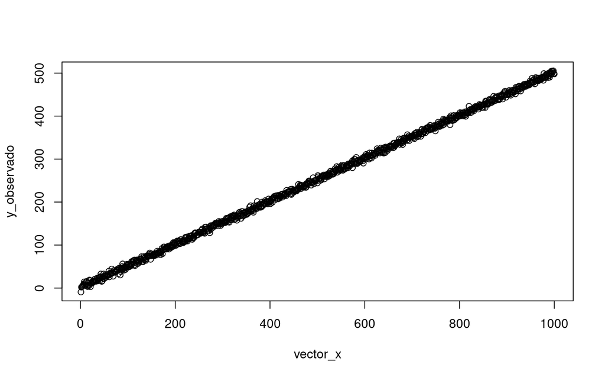

```r
plot(vector_x,y_observado)
```

# Modelo lineal

```r
modelo_y_predicho <- lm(y_observado ~ vector_x)

y_predicho <- predict(modelo_y_predicho)

print(y_predicho)
```

```
##          1          2          3          4          5          6          7
##   2.650034   3.149898   3.649763   4.149627   4.649491   5.149356   5.649220
##          8          9         10         11         12         13         14
##   6.149084   6.648949   7.148813   7.648678   8.148542   8.648406   9.148271
##         15         16         17         18         19         20         21
##   9.648135  10.148000  10.647864  11.147728  11.647593  12.147457  12.647322
##         22         23         24         25         26         27         28
##  13.147186  13.647050  14.146915  14.646779  15.146643  15.646508  16.146372
##         29         30         31         32         33         34         35
##  16.646237  17.146101  17.645965  18.145830  18.645694  19.145559  19.645423
##         36         37         38         39         40         41         42
##  20.145287  20.645152  21.145016  21.644881  22.144745  22.644609  23.144474
##         43         44         45         46         47         48         49
##  23.644338  24.144202  24.644067  25.143931  25.643796  26.143660  26.643524
##         50         51         52         53         54         55         56
##  27.143389  27.643253  28.143118  28.642982  29.142846  29.642711  30.142575
##         57         58         59         60         61         62         63
##  30.642440  31.142304  31.642168  32.142033  32.641897  33.141761  33.641626
##         64         65         66         67         68         69         70
##  34.141490  34.641355  35.141219  35.641083  36.140948  36.640812  37.140677
##         71         72         73         74         75         76         77
##  37.640541  38.140405  38.640270  39.140134  39.639999  40.139863  40.639727
##         78         79         80         81         82         83         84
##  41.139592  41.639456  42.139320  42.639185  43.139049  43.638914  44.138778
##         85         86         87         88         89         90         91
##  44.638642  45.138507  45.638371  46.138236  46.638100  47.137964  47.637829
##         92         93         94         95         96         97         98
##  48.137693  48.637558  49.137422  49.637286  50.137151  50.637015  51.136879
##         99        100        101        102        103        104        105
##  51.636744  52.136608  52.636473  53.136337  53.636201  54.136066  54.635930
##        106        107        108        109        110        111        112
##  55.135795  55.635659  56.135523  56.635388  57.135252  57.635117  58.134981
##        113        114        115        116        117        118        119
##  58.634845  59.134710  59.634574  60.134438  60.634303  61.134167  61.634032
##        120        121        122        123        124        125        126
##  62.133896  62.633760  63.133625  63.633489  64.133354  64.633218  65.133082
##        127        128        129        130        131        132        133
##  65.632947  66.132811  66.632676  67.132540  67.632404  68.132269  68.632133
##        134        135        136        137        138        139        140
##  69.131997  69.631862  70.131726  70.631591  71.131455  71.631319  72.131184
```

[output cut: 231 more lines]

```
## 475.021881 475.521745 476.021610 476.521474 477.021339 477.521203 478.021067
##        953        954        955        956        957        958        959
## 478.520932 479.020796 479.520660 480.020525 480.520389 481.020254 481.520118
##        960        961        962        963        964        965        966
## 482.019982 482.519847 483.019711 483.519576 484.019440 484.519304 485.019169
##        967        968        969        970        971        972        973
## 485.519033 486.018898 486.518762 487.018626 487.518491 488.018355 488.518219
##        974        975        976        977        978        979        980
## 489.018084 489.517948 490.017813 490.517677 491.017541 491.517406 492.017270
##        981        982        983        984        985        986        987
## 492.517135 493.016999 493.516863 494.016728 494.516592 495.016457 495.516321
##        988        989        990        991        992        993        994
## 496.016185 496.516050 497.015914 497.515778 498.015643 498.515507 499.015372
##        995        996        997        998        999       1000
## 499.515236 500.015100 500.514965 501.014829 501.514694 502.014558
```